# Split Strategies: Sensible Defaults for Validation

Auto-selecting the right validation strategy based on task type and data size

Published

May 4, 2026

The `select_validation_plan()` function auto-selects the right validation strategy based on your task type and data size. No more deciding between `train_test_split` and `TimeSeriesSplit` — just tell it what kind of data you have.

This tutorial demonstrates:

1. **One-call API** — one function, correct strategy
2. **Task-type awareness** — temporal vs random, and the cost of getting it wrong
3. **Small-data auto-CV** — KFold kicks in automatically when data is scarce
4. **Hybrid mode** — outer holdout + inner CV for robust tuning

```python
import numpy as np
import polars as pl
import matplotlib.pyplot as plt
from sklearn.ensemble import GradientBoostingRegressor

from uncertainty_flow.metrics import coverage_score, winkler_score
from uncertainty_flow.utils.split import (
    select_validation_plan,
    RandomHoldoutSplit,
    TemporalHoldoutSplit,
)
from uncertainty_flow.utils import ValidationSplitPlan
from uncertainty_flow.wrappers import ConformalForecaster
```

## 1. The One-Call API

Instead of manually slicing data and guessing the right split strategy, just call:

```python
plan = select_validation_plan(data, task_type="tabular", random_state=42)
train, val = plan.outer_split
```

The function inspects your **task type** and **data size**, then selects the correct strategy. Let’s see it in action.

```python
df_tabular = pl.read_parquet("../data/concrete.parquet")
plan_tabular = select_validation_plan(df_tabular, task_type="tabular", random_state=42)
plan_tabular.metadata
```

```
SplitPlanMetadata(strategy_name='random_holdout', reason='tabular task defaults to random holdout', n_samples=1030, n_splits=1, holdout_fraction=0.2, random_state=42, hybrid_mode=False, task_type='tabular')
```

```python
df_ts = pl.read_parquet("../data/weather.parquet").drop_nulls()
plan_ts = select_validation_plan(df_ts, task_type="time_series", random_state=42)
plan_ts.metadata
```

```
SplitPlanMetadata(strategy_name='temporal_holdout', reason='time_series task defaults to temporal holdout', n_samples=36887, n_splits=1, holdout_fraction=0.2, random_state=42, hybrid_mode=False, task_type='time_series')
```

**Key observations:** - Tabular data → `random_holdout` (exchangeability assumption holds) - Time series → `temporal_holdout` (preserves temporal ordering, prevents leakage) - No manual `df[:split]` slicing needed

## 2. Task-Type Awareness: The Cost of Wrong Splits

Below we compare two split strategies on weather time series: - Temporal holdout (correct) — trains on past, evaluates on future - Random holdout (wrong) — shuffles data, leaking future into training

We then train a `ConformalForecaster` with each split and compare metrics.

```python
target = "T (degC)"
horizon = 6
df_small = df_ts.select(target).head(2000)

temporal = TemporalHoldoutSplit()
temp_train, temp_val = temporal.split(df_small, 0.2)
temp_model = ConformalForecaster(
    base_model=GradientBoostingRegressor(random_state=42),
    targets=target,
    horizon=horizon,
    lags=3,
    calibration_size=0.2,
    auto_tune=False,
    random_state=42,
)
temp_model.fit(temp_train)
temp_pred = temp_model.predict(temp_val)
temp_interval = temp_pred.interval(0.9)
temp_y_true = temp_val[target].to_numpy()[-len(temp_interval):]
temp_coverage = coverage_score(temp_y_true, temp_interval["lower"].to_numpy(), temp_interval["upper"].to_numpy())
temp_winkler = winkler_score(temp_y_true, temp_interval["lower"].to_numpy(), temp_interval["upper"].to_numpy(), confidence=0.9)

random = RandomHoldoutSplit(random_state=42)
rand_train, rand_val = random.split(df_small, 0.2)
rand_model = ConformalForecaster(
    base_model=GradientBoostingRegressor(random_state=42),
    targets=target,
    horizon=horizon,
    lags=3,
    calibration_size=0.2,
    auto_tune=False,
    random_state=42,
)
rand_model.fit(rand_train)
rand_pred = rand_model.predict(rand_val)
rand_interval = rand_pred.interval(0.9)
rand_y_true = rand_val[target].to_numpy()[-len(rand_interval):]
rand_coverage = coverage_score(rand_y_true, rand_interval["lower"].to_numpy(), rand_interval["upper"].to_numpy())
rand_winkler = winkler_score(rand_y_true, rand_interval["lower"].to_numpy(), rand_interval["upper"].to_numpy(), confidence=0.9)
```

```python
metrics_df = pl.DataFrame({
    "Strategy": ["Temporal Holdout (correct)", "Random Holdout (leakage)"],
    "Coverage (90% target)": [f"{temp_coverage:.3f}", f"{rand_coverage:.3f}"],
    "Winkler Score": [f"{temp_winkler:.3f}", f"{rand_winkler:.3f}"],
})
metrics_df
```

shape: (2, 3)

| Strategy str | Coverage (90% target) str | Winkler Score str |
| --- | --- | --- |
| "Temporal Holdout (correct)" | "0.763" | "0.338" |
| "Random Holdout (leakage)" | "0.763" | "0.338" |

## 3. Small-Data Auto-CV

When your dataset has **fewer than 250 rows**, `select_validation_plan` automatically switches from a single holdout to **KFold cross-validation**. This gives more stable tuning at the cost of some bias.

Let’s see it in action — subset the concrete data to just 120 rows.

```python
df_small_tab = df_tabular.head(120)
plan_small = select_validation_plan(df_small_tab, task_type="tabular", random_state=42)
plan_small.metadata
```

```
SplitPlanMetadata(strategy_name='kfold_cv', reason='small tabular dataset uses CV for more stable tuning', n_samples=120, n_splits=5, holdout_fraction=0.2, random_state=42, hybrid_mode=False, task_type='tabular')
```

Notice: `strategy_name` changed from `random_holdout` to `kfold_cv`, and `n_splits` > 1. The plan now includes `inner_splits` — multiple train/validation folds.

Let’s compare tuning stability between single holdout and CV for a small dataset.

```python
_target = "strength"

single_holdout_scores = []
cv_scores = []

for seed in range(20):
    plan = select_validation_plan(df_small_tab, task_type="tabular", random_state=seed)
    if plan.inner_splits:
        fold_scores = []
        for split_train, split_val in plan.inner_splits:
            model = GradientBoostingRegressor(n_estimators=30, random_state=seed)
            model.fit(
                split_train.select([c for c in split_train.columns if c != _target]).to_numpy(),
                split_train[_target].to_numpy(),
            )
            preds = model.predict(
                split_val.select([c for c in split_val.columns if c != _target]).to_numpy()
            )
            err = float(np.mean(np.abs(preds - split_val[_target].to_numpy())))
            fold_scores.append(err)
        cv_scores.append(float(np.mean(fold_scores)))

    splitter = RandomHoldoutSplit(random_state=seed)
    s_train, s_val = splitter.split(df_small_tab, 0.2)
    model = GradientBoostingRegressor(n_estimators=30, random_state=seed)
    model.fit(
        s_train.select([c for c in s_train.columns if c != _target]).to_numpy(),
        s_train[_target].to_numpy(),
    )
    preds = model.predict(
        s_val.select([c for c in s_val.columns if c != _target]).to_numpy()
    )
    score = float(np.mean(np.abs(preds - s_val[_target].to_numpy())))
    single_holdout_scores.append(score)
```

[output not shown]

[output cut: 23 more lines]

[output not shown]

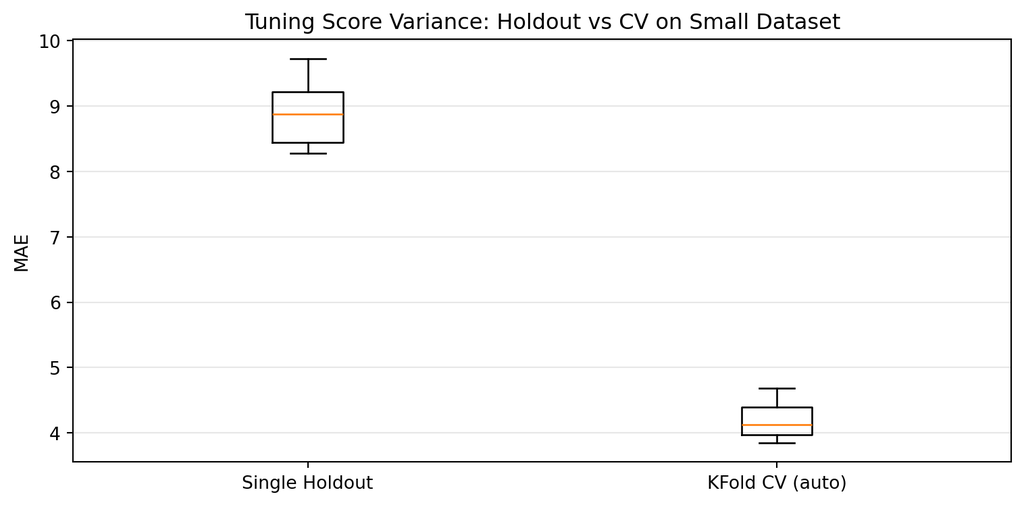

```python
fig, ax = plt.subplots(figsize=(8, 4))
ax.boxplot([single_holdout_scores, cv_scores], tick_labels=["Single Holdout", "KFold CV (auto)"])
ax.set_ylabel("MAE")
ax.set_title("Tuning Score Variance: Holdout vs CV on Small Dataset")
ax.grid(axis="y", alpha=0.3)
plt.tight_layout()
plt.show()
```

```python
holdout_var = float(np.var(single_holdout_scores))
cv_var = float(np.var(cv_scores))
reduction = (1 - cv_var / holdout_var) * 100
print(f"Holdout variance: {holdout_var:.6f}  |  CV variance: {cv_var:.6f}  |  Variance reduction: {reduction:.0f}%")
```

```
Holdout variance: 0.202906  |  CV variance: 0.059566  |  Variance reduction: 71%
```

## 4. Hybrid Mode: Outer Holdout + Inner CV

Sometimes you want **both**: a clean outer holdout for final evaluation, plus inner CV folds for robust hyperparameter tuning.

Enable this with `hybrid_mode=True`:

```python
plan = select_validation_plan(data, task_type="tabular",
                               hybrid_mode=True, random_state=42)
```

- `plan.outer_split` → held-out test set
- `plan.inner_splits` → CV folds from the training portion

```python
plan_hybrid = select_validation_plan(
    df_tabular, task_type="tabular", hybrid_mode=True, random_state=42
)
plan_hybrid.metadata
```

```
SplitPlanMetadata(strategy_name='random_outer_plus_oos_inner_cv', reason='hybrid mode enabled: out-of-sample outer and inner validation', n_samples=1030, n_splits=5, holdout_fraction=0.2, random_state=42, hybrid_mode=True, task_type='tabular')
```

```python
print(f"Inner CV folds: {len(plan_hybrid.inner_splits)}  |  Outer train rows: {len(plan_hybrid.outer_split[0])}  |  Outer test rows: {len(plan_hybrid.outer_split[1])}")
```

```
Inner CV folds: 5  |  Outer train rows: 824  |  Outer test rows: 206
```

## 5. Hybrid Mode for Time Series

```python
plan_hybrid_ts = select_validation_plan(
    df_ts.head(2000), task_type="time_series", hybrid_mode=True, random_state=42
)
plan_hybrid_ts.metadata
```

```
SplitPlanMetadata(strategy_name='temporal_outer_plus_oos_inner_cv', reason='hybrid mode enabled: temporal outer split with out-of-sample inner CV', n_samples=2000, n_splits=5, holdout_fraction=0.2, random_state=42, hybrid_mode=True, task_type='time_series')
```

This is the best of both worlds: no data leakage in the final evaluation, plus stable tuning across multiple train/validation splits.

## 6. Summary: When to Use What

```python
summary_df = pl.DataFrame({
    "Task Type": ["Tabular (large)", "Tabular (small, <250 rows)", "Time Series"],
    "Auto Strategy": ["Random Holdout", "KFold CV", "Temporal Holdout"],
    "Why": ["Exchangeability holds; single split is fast", "Single split too noisy; CV reduces variance", "Preserves ordering; prevents leakage"],
    "Hybrid": ["Adds CV for tuning stability", "CV + outer holdout for final eval", "Temporal outer + OOS inner CV"],
})
```

**Bottom line:** Use `select_validation_plan(data, task_type=...)` as your default split strategy. It handles the edge cases so you don’t have to think about them.

```python
summary_df
```

shape: (3, 4)

| Task Type str | Auto Strategy str | Why str | Hybrid str |
| --- | --- | --- | --- |
| "Tabular (large)" | "Random Holdout" | "Exchangeability holds; single … | "Adds CV for tuning stability" |
| "Tabular (small, <250 rows)" | "KFold CV" | "Single split too noisy; CV red… | "CV + outer holdout for final e… |
| "Time Series" | "Temporal Holdout" | "Preserves ordering; prevents l… | "Temporal outer + OOS inner CV" |